# Challenge B

Valérie Furio and Anna Tenias

08/12/2017

We couldn’t write down in the code to install the different packages needed so here are a list of what they are :

- tidyverse
- np
- caret
- readr
- ggplot2

# Task 1B - Predicting Houses Prices in Ames, Iowa

### Question 1

We chose to study the Non-Parametric Kernel estimation. This method attempts to estimate the density directly from the data and it is non parametric because we do not assume a particular form for the underlying distribution. It is similar to histogram except boxes are subsitued by a Gaussian density. We choose a target point and the more the obersation is close to the target point the more the curve will give an important value. The assaigned weight will die off toward 0 in a continuous fashion way as we getfurther away from the target point. The estiamation is formed by the mean of the dfiferent bell curves.

### Question 2

First we are going to import the training data from the csv file

```r
library(tidyverse)
datatrain <-  read.csv(file="/Users/annatenias/Desktop/train.csv", header=TRUE, sep=",")
attach(datatrain)
```

Then we are going to remove the column Id because it is not usefull

```r
datatrain$Id <- NULL
head(datatrain)
```

```
##   MSSubClass MSZoning LotFrontage LotArea Street Alley LotShape
## 1         60       RL          65    8450   Pave  <NA>      Reg
## 2         20       RL          80    9600   Pave  <NA>      Reg
## 3         60       RL          68   11250   Pave  <NA>      IR1
## 4         70       RL          60    9550   Pave  <NA>      IR1
## 5         60       RL          84   14260   Pave  <NA>      IR1
## 6         50       RL          85   14115   Pave  <NA>      IR1
##   LandContour Utilities LotConfig LandSlope Neighborhood Condition1
## 1         Lvl    AllPub    Inside       Gtl      CollgCr       Norm
## 2         Lvl    AllPub       FR2       Gtl      Veenker      Feedr
## 3         Lvl    AllPub    Inside       Gtl      CollgCr       Norm
## 4         Lvl    AllPub    Corner       Gtl      Crawfor       Norm
## 5         Lvl    AllPub       FR2       Gtl      NoRidge       Norm
## 6         Lvl    AllPub    Inside       Gtl      Mitchel       Norm
##   Condition2 BldgType HouseStyle OverallQual OverallCond YearBuilt
```

[output cut: 76 more lines]

First we are going to look for the variables with missing data

```r
datatrain %>% summarise_all(.funs = funs(sum(is.na(.)))) %>% gather(key = "feature", value = "missing.observations") %>% filter(missing.observations > 0)
```

```
##         feature missing.observations
## 1   LotFrontage                  259
## 2         Alley                 1369
## 3    MasVnrType                    8
## 4    MasVnrArea                    8
## 5      BsmtQual                   37
## 6      BsmtCond                   37
## 7  BsmtExposure                   38
## 8  BsmtFinType1                   37
## 9  BsmtFinType2                   38
## 10   Electrical                    1
## 11  FireplaceQu                  690
## 12   GarageType                   81
## 13  GarageYrBlt                   81
## 14 GarageFinish                   81
## 15   GarageQual                   81
## 16   GarageCond                   81
## 17       PoolQC                 1453
## 18        Fence                 1179
## 19  MiscFeature                 1406
```

Now we are going to remove the variables with more than 100 missing values

```r
remove.vars <- datatrain %>% summarise_all(.funs = funs(sum(is.na(.)))) %>% gather(key = "feature",
                                                                               value = "missing.observations") %>% filter(missing.observations > 100) %>% select(feature) %>% unlist

datatrain <- datatrain %>% select(- one_of(remove.vars))
```

For the rest of the observations, we remove the ones with missing values

```r
datatrain %>% summarise_all(.funs = funs(sum(is.na(.)))) %>% gather(key = "feature", value = "missing.observations") %>% filter(missing.observations > 0)
```

```
##         feature missing.observations
## 1    MasVnrType                    8
## 2    MasVnrArea                    8
## 3      BsmtQual                   37
## 4      BsmtCond                   37
## 5  BsmtExposure                   38
## 6  BsmtFinType1                   37
## 7  BsmtFinType2                   38
## 8    Electrical                    1
## 9    GarageType                   81
## 10  GarageYrBlt                   81
## 11 GarageFinish                   81
## 12   GarageQual                   81
## 13   GarageCond                   81
```

```r
datatrain <- datatrain %>% filter(is.na(GarageType) == FALSE, is.na(MasVnrType) == FALSE, is.na(BsmtFinType2) == FALSE, is.na(BsmtExposure) == FALSE, is.na(Electrical) == FALSE)
```

remove rows with NA in some of these variables, check if you take all missing values like this

make sure it’s all clean : Yes

```r
datatrain %>% summarise_all(.funs = funs(sum(is.na(.)))) %>% gather(key = "feature", value = "missing.observations") %>% filter(missing.observations > 0)
```

```
## [1] feature              missing.observations
## <0 rows> (or 0-length row.names)
```

Now we are going to convert al character variables into factor

```r
cat_var <- datatrain %>% summarise_all(.funs = funs(is.character(.))) %>% gather(key = "feature", value = "is.chr") %>% filter(is.chr == TRUE) %>% select(feature) %>% unlist

datatrain %>% mutate_at(.cols = cat_var, .funs = as.factor)
```

```
## `.cols` has been renamed and is deprecated, please use `.vars`
```

[output not shown]

[output cut: 17392 more lines]

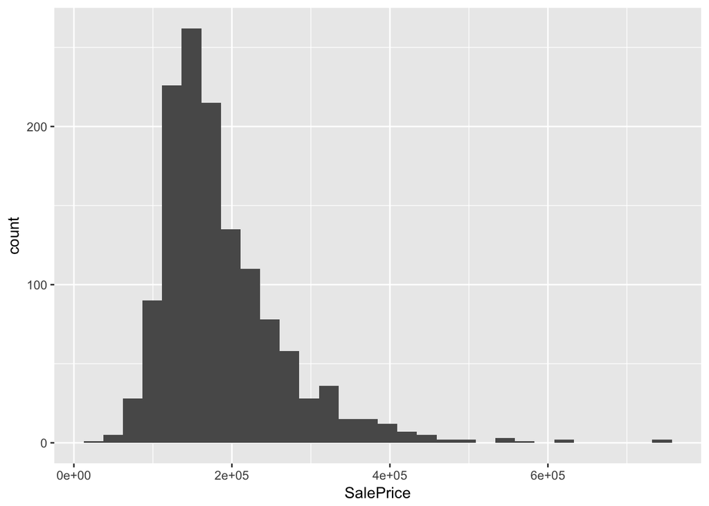

```r
ggplot(data = datatrain) + geom_histogram(mapping = aes( x = SalePrice))
```

```r
library(np)
```

Now we are going to compute a kernel regression estimate using the npreg function, it will also computa bandwith specification using the method of Racine and Li

For the next par of the code we had to take it off because Rarkdown wouldn’t knit (it took too long)

ModelSP <- npreg(SalePrice ~ MSZoning + LotArea + Neighborhood + YearBuilt + OverallQual, data = datatrain) summary(ModelSP)

### Question 3

Since we couldn’t knit the file with the previous question be couldn’t knit it with the following code but you can run it from the rmd file in our github repo (https://github.com/AnnaTenias/Challenge-B) First we are going to import the test data

datatest <- read.csv(file=“/Users/annatenias/Desktop/test.csv”, header=TRUE, sep=“,”)

predictionstest <- predict(ModelSP, newdata=datatest) prediction <- data.frame(predictionstest)

mean(predictionstest)

lets see what the predictions are with our lm model witch is the one from the correction

lm_model_2 <- lm(SalePrice ~ MSZoning + LotArea + Neighborhood + YearBuilt + OverallQual, data = datatrain)

predictionlm <- predict(lm_model_2, newdata = datatest) predictionLM <- data.frame(predictionlm)

# Task 2B - Overfitting in Machine Learning

I the first time we are taking the correction’s code to recreate the model.

```r
rm(list = ls()) #clean environment, remove all variables/data created before
```

Simulating an overfit

```r
library(tidyverse)
library(np)
library(caret)
```

```r
# True model : y = x^3 + epsilon
set.seed(1) # very important for replication
Nsim <- 150 # Nsim = number of simulations
b <- c(0,1) #
x0 <- rep(1, Nsim)
x1 <- rnorm(n = Nsim) # x1 is x from the question, I draw here a vector of size Nsim of x from a normal N(0,1)

X <- cbind(x0, x1^3) # this is X such that y = Xb + epsilon, so X = 0 + x^3 = x0 + x1^3
# x0 is a vector of 0, x1 is a random vector of size Nsim drawn from normal N(0,1)
y.true <- X %*% b

eps <- rnorm(n = Nsim) # draw a vector of size Nsim from normal N(0,1), this is epsilon
y <- X %*% b + eps # the simulated y is then computed following the true model

df <- tbl_df(y[,1]) %>% rename(y = value) %>% bind_cols(tbl_df(x1)) %>% rename(x = value) %>% bind_cols(tbl_df(y.true[,1])) %>% rename(y.true = value) # the previous y and x are matrix and vector, I transform them into a dataframe to use the tidyverse
```

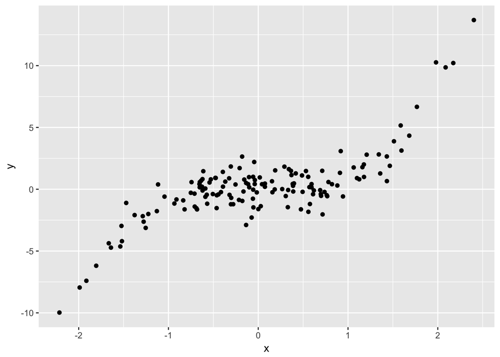

```r
ggplot(df) + geom_point(mapping = aes(x = x, y = y))
```

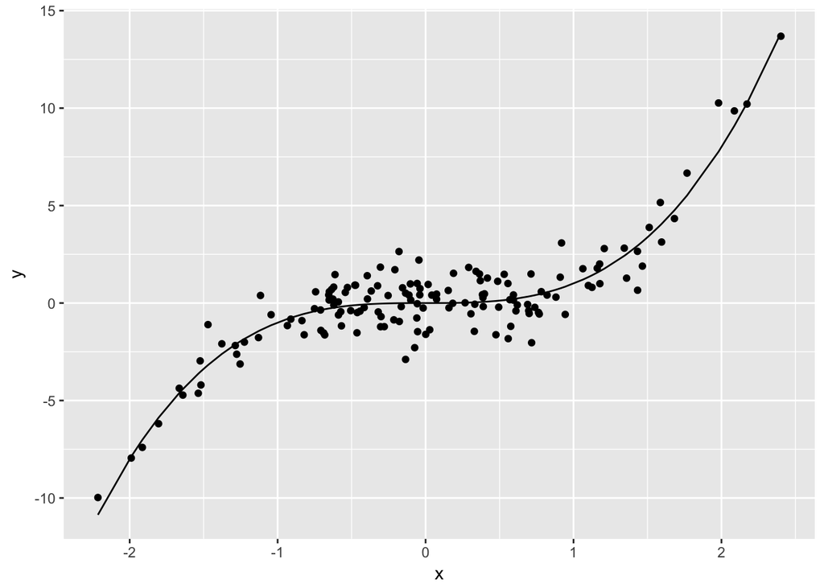

```r
ggplot(df) + geom_point(mapping = aes(x = x, y = y)) +
  geom_line(mapping = aes(x = x, y = y.true)) # I store the true model f(x) = x^3 (or the best prediction line)  in the column y.true of the data.frame df, and I draw it by adding geom_line to the scatter plot
```

Split sample into training and testing, 80/20

```r
training.index <- createDataPartition(y = y, times = 1, p = 0.8) #index of the rows I want to keep
df <- df %>% mutate(which.data = ifelse(1:n() %in% training.index$Resample1, "training", "test")) # I create a new column in df (thus the function mutate) that is categorical and is equal to training if the index of the row (i compute through 1:n()) is in the vector training.index; remember training.index contains the number of the rows that are randomly selected into the training set.

training <- df %>% filter(which.data == "training") #here i subset the table into a training sub-table and a test sub-table
test <- df %>% filter(which.data == "test")
```

Train linear model y ~ x on training

```r
lm.fit <- lm(y ~ x, data = training) #regress y on x only on training data
summary(lm.fit)
```

```
##
## Call:
## lm(formula = y ~ x, data = training)
##
## Residuals:
##     Min      1Q  Median      3Q     Max
## -4.7575 -1.0695  0.0419  1.0229  7.6216
##
## Coefficients:
##             Estimate Std. Error t value Pr(>|t|)
## (Intercept)   0.1950     0.1649   1.183    0.239
## x             2.4446     0.1846  13.241   <2e-16 ***
## ---
## Signif. codes:  0 '***' 0.001 '**' 0.01 '*' 0.05 '.' 0.1 ' ' 1
##
## Residual standard error: 1.82 on 120 degrees of freedom
## Multiple R-squared:  0.5937, Adjusted R-squared:  0.5903
## F-statistic: 175.3 on 1 and 120 DF,  p-value: < 2.2e-16
```

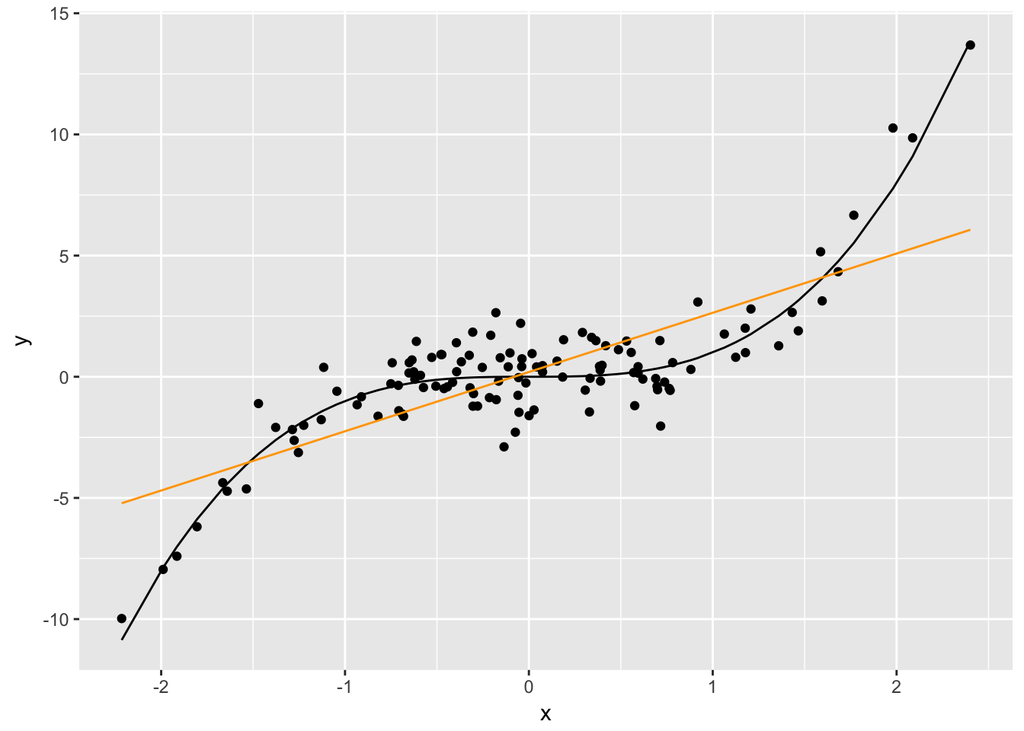

```r
training <- training %>% mutate(y.lm = predict(object = lm.fit))
# I add a column to training that has the linear model predictions, then I plot them
ggplot(training) + geom_point(mapping = aes(x = x, y = y)) +
  geom_line(mapping = aes(x = x, y = y.true)) +
  geom_line(mapping = aes(x = x, y = y.lm), color = "orange")
```

```r
# same plot as before with scatterplot and true line, now add orange line of predictions from linear model.
```

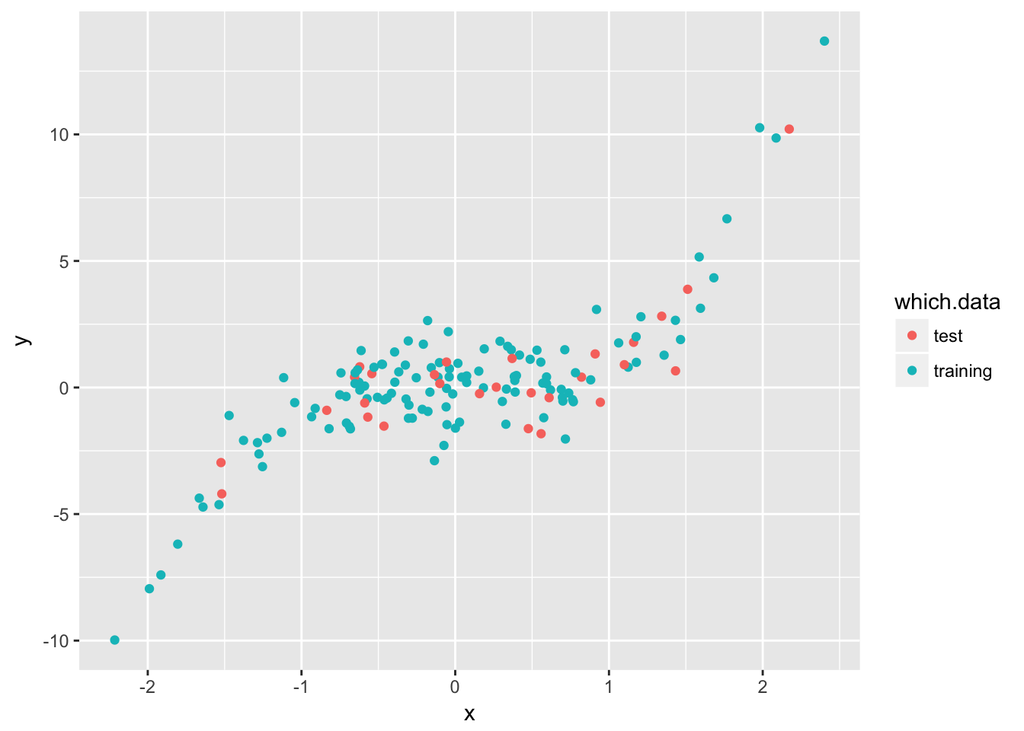

```r
ggplot(df) + geom_point(mapping = aes(x = x, y = y, color = which.data))
```

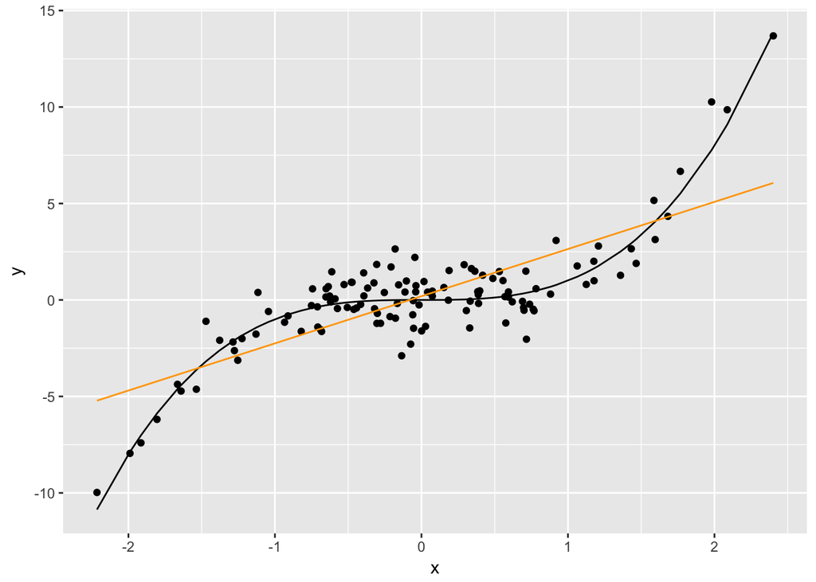

```r
ggplot(training) + geom_point(mapping = aes(x = x, y = y)) +
  geom_line(mapping = aes(x = x, y = y.true)) +
  geom_line(mapping = aes(x = x, y = y.lm), color = "orange")
```

Now this is our code :

### Question 1. Estimate a low-flexibility local linear model on the training data with function npreg

First with a bandwidth of 0.5:

```r
ll.fit.lowflex <- npreg(y ~ x,
                        method="ll",
                        bws=0.5,
                        data=training)
```

### Question 2. Estimate a high-flexibility local linear model on the training data with function npreg

Now with a bandwidth of 0.01:

```r
ll.fit.highflex <- npreg(y ~ x,
                        method="ll",
                        bws=0.01,
                        data=training)
```

### Question 3. Plot the scatterplot of x-y and predictions (low and high)

First we put the predictions of the low flexibility model and the high flexibility model in the same table using function mutate:

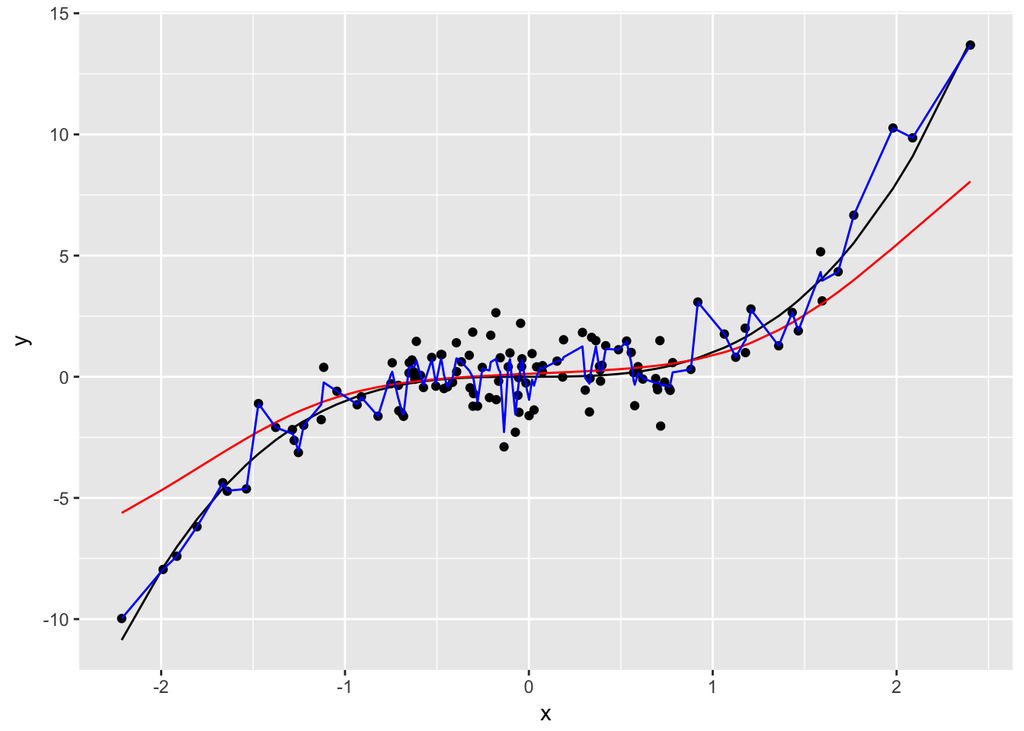

```r
trainingLowHigh <- training %>% mutate(y.low = predict(object = ll.fit.lowflex)) %>% mutate(y.high = predict(object = ll.fit.highflex))

# Finally we construct the plot
ggplot(trainingLowHigh) + geom_point(mapping = aes(x = x, y = y)) + # the scatter points
  geom_line(mapping = aes(x = x, y = y.true)) + # the "true" curve
  geom_line(mapping = aes(x = x, y = y.low), color = "red") +# low-flexibility predictions
  geom_line(mapping = aes(x = x, y = y.high), color = "blue") # low-flexibility predictions
```

### Question 4.

Comments: The bias is how far off on the average the model is from the truth, while the variance tells us how much of the estimate varies around its average. We know that, as flexibility increases, typically the bias decreases but the variance increases Between the two models, the blue line, which is the high-flexibility model, seems to be the most variable and the least biased. This makes sense as we estimated the model on this data.

### Question 5. Use the two models to produce predictions on the test data

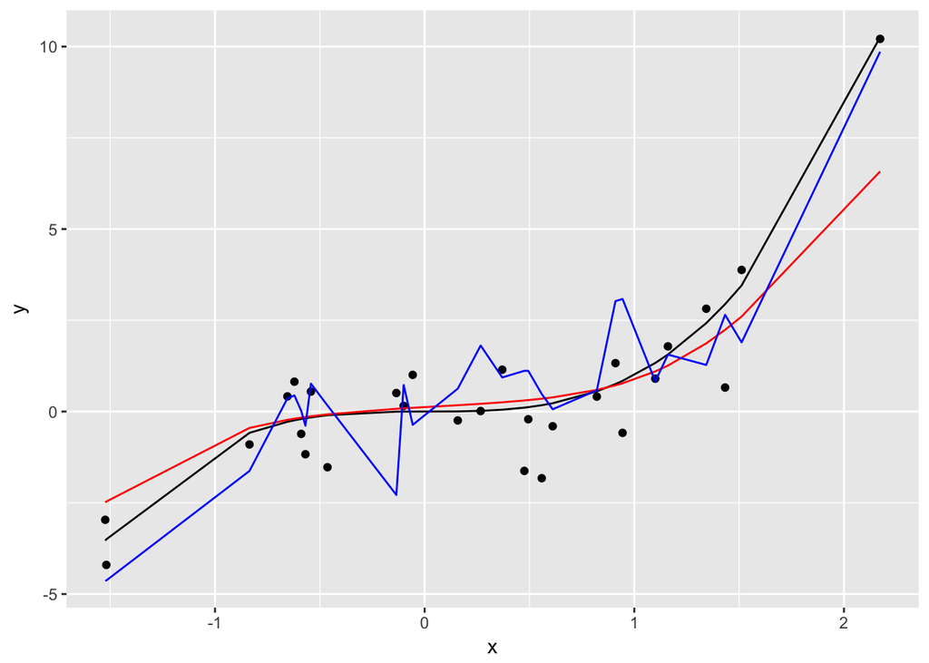

```r
lowflex.test <- predict(ll.fit.lowflex,newdata=test) # We use the low-flexibility model to predict the test data
highflex.test <- predict(ll.fit.highflex,newdata=test) # We use the high-flexibility model to predict the test data
BW0.01_0.5.Test <- test %>% mutate(lowflex.test) %>% mutate(highflex.test) # We put them in the same table to be able to plot them

# Finally, we plot it:
ggplot(BW0.01_0.5.Test) + geom_point(mapping = aes(x = x, y = y)) + # the scatter points
  geom_line(mapping = aes(x = x, y = y.true)) + # the "true" curve
  geom_line(mapping = aes(x = x, y = lowflex.test), color = "red") + # low-flexibility predictions on the test data
  geom_line(mapping = aes(x = x, y = highflex.test), color = "blue") # low-flexibility predictions on the test data
```

Let’s look at the mean square error, which gives us the overall error rate. MSE = (1/n)(ymodel - y)^2

### Question 6. Create a vector for the bandwidth:

```r
bandwidth <- seq(0.01,0.5,0.001) # This creates a vector from 0.01 to 0.5 with a step of 0.001
```

### Question 7. Estimate a local linear model y ~ x on the training data with each bandwidth:

First, we create a function to be able to use lapply after:

```r
Npregfunction <- function(i){
                        npreg(y~x,method="ll",bws=i,data=training)}

# We use the function lapply to create a model for each bandwidth:
Npreg.bw.vector <- lapply(bandwidth,Npregfunction)
```

### Question 8. Compute for each bandwidth the MSE on the training data:

We compute the MSE function directly. We know n=122 for the training data:

We create a function to be able to use sapply after:

```r
mse.function <- function(i){((1/122)*sum(((fitted.values(i)-training$y)^2)))}

# We use sapply to create a vector with all the MSE values from the training data:
mse.bw.vector <- sapply(Npreg.bw.vector,mse.function)
```

### Question 9. Compute for each bandwidth the MSE on the test data:

Here we directly find the predictions and then calculate MSE

We create a function for the predictions, to be used with lapply after: We can just use the function the function we created for the training data, Npregfunction

```r
test.prediction.function <- function(i){predict(Npregfunction(i),newdata=test)}

# We use lapply to create a list of the predictions for all of the bandwidths:
Npreg.bw.vector.test <- lapply(bandwidth,test.prediction.function)

## Calculate MSE on the test data. We know that n=28 here.

# We create a function to be able to use sapply after:
mse.function.test <- function(i){((1/28)*sum(((test.prediction.function(i)-test$y)^2)))}

# We use sapply to create a vector with all the MSE values from the test data:
MSE.test <- sapply(bandwidth,mse.function.test)
```

### Question 10. We draw this on the same plot

We create a table with the bandwidth, the MSE for the training data, and the MSE for the test data:

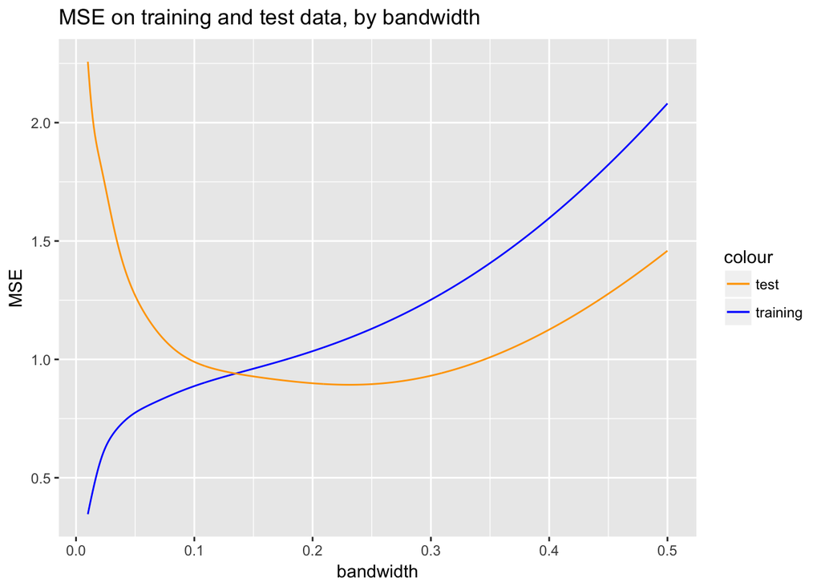

```r
MSE.bandwidth.table <- data.frame(bandwidth,mse.bw.vector,MSE.test)

# And we plot it!
ggplot(MSE.bandwidth.table) +
  geom_line(mapping = aes(x = bandwidth, y = mse.bw.vector,colour = "training")) + # MSE on the training data
  geom_line(mapping = aes(x = bandwidth, y = MSE.test,colour = "test")) + # MSE on the test data
  scale_color_manual(values = c(training = "blue", test = "orange")) + # Colour legend
  labs (title="MSE on training and test data, by bandwidth",y="MSE") # Title and legend
```

# Task 3B - Privacy Regulation Compliance in France

```r
rm(list = ls()) # Clean data
```

### STEP 1 : Import the CNIL dataset from the Open Data Portal

We are importing the data using the .csv file

```r
CNILdata <- read.csv(file="/Users/annatenias/Desktop/CNIL_Organismes.csv", header=TRUE, sep=";")
summary(CNILdata)
```

```
##      Siren
##  Min.   :        0
##  1st Qu.:328921047
##  Median :413669820
##  Mean   :456909330
##  3rd Qu.:519605918
##  Max.   :999999999
##  NA's   :302
##                                           Responsable
##  N.F.L. DISTRIBUTION                            :   16
##  CENTRE COMMUNAL D'ACTION SOCIALE               :    7
##  CHAMBRE DEPARTEMENTALE DES HUISSIERS DE JUSTICE:    7
##  BAYER S.A.S.                                   :    6
##  CAISSE PRIMAIRE D'ASSURANCE MALADIE            :    6
##  MAIRIE                                         :    6
##  (Other)                                        :18496
##                 Adresse       Code_Postal           Ville
##  11 RUE EMILE BRAULT:  206   75008  :  347   PARIS     : 1871
##  MAIRIE             :  195   75009  :  272   LYON      :  226
##  115 RUE DE LA SANTE:   92   53000  :  222   LAVAL     :  222
##                     :   61   75013  :  147   MARSEILLE :  180
##  8 AVENUE DELCASSE  :   38   75017  :  134   TOULOUSE  :  108
##  LE BOURG           :   29   75015  :  127   STRASBOURG:   96
##  (Other)            :17923   (Other):17295   (Other)   :15841
##                                                                                        NAF
##  6910Z Activités juridiques                                                              :2689
##  741A Activités juridiques, comptables et de conseil de gestion                          :2379
##  8810A Action sociale sans hébergement pour personnes âgées et pour personnes handicapées:1794
##  8411Z Administration générale, économique et sociale                                    : 746
##                                                                                          : 613
##  4711D Commerce de détail en magasin non spécialisé                                      : 453
##  (Other)                                                                                 :9870
##           TypeCIL           Portee
##               : 119   Etendue  :16928
##  EXTERNE      : 901   Générale : 1316
##  INTERNE      :4359   Partielle:  300
##  MUTUALISE    :3757
##  PROFESSIONNEL:8918
##  SALARIE      : 490
##
```

```r
attach(CNILdata)
newCNILdata <- CNILdata # We work on this
```

### STEP 2 : Show a table with the number of organizations that has nominated a CNIL per department

We first create a new column with the first two characters of the column ‘Code Postal’ This will give us, with a small margin of error, the department of the CNIL

```r
library(tidyverse)
CNIL1 <- newCNILdata %>% mutate(Department = substr(newCNILdata$Code_Postal, 0, 2))
head(CNIL1,5)
```

```
##       Siren     Responsable                      Adresse Code_Postal
## 1 788349926 "LA RIVE BLEUE"              3/5 RUE BOILEAU       49100
## 2 421715731       01 DIRECT      58 AVENUE DE RIVESALTES       66240
## 3 409869708   01DB-METRAVIB       200 CHEMIN DES ORMEAUX       69760
## 4 444600464      1.2.3. SAS 57-59 -61 RUE HENRI BARBUSSE       92110
## 5 922002968  100 % ASNIERES       70 AVENUE D'ARGENTEUIL       92600
##          Ville                                                   NAF
## 1       ANGERS           8790A Autres activités d'hébergement social
## 2 SAINT ESTEVE                  526B Commerce de détail hors magasin
## 3     LIMONEST    7120B Activités de contrôle et analyses techniques
## 4       CLICHY 524C Autres commerces de détail en magasin spécialisé
## 5     ASNIERES                913C Autres organisations associatives
##         TypeCIL   Portee Department
## 1       INTERNE  Etendue         49
## 2       EXTERNE Générale         66
## 3 PROFESSIONNEL  Etendue         69
## 4       EXTERNE  Etendue         92
## 5       INTERNE  Etendue         92
```

We clean some of the mistakes that were made when finding the department:

```r
CNIL1$Department[CNIL1$Department == ""] <- "Other" #Unknown
CNIL1$Department[CNIL1$Department == "."] <- "Other" #Unknown
```

Some more manual cleaning… (We create a new dataframe in case of a mistake)

```r
CNIL2 <- CNIL1
CNIL2$Department[CNIL1$Department == "PA"] <- 75
CNIL2$Department[CNIL1$Department == "W1"] <- "Other" #This is in London
CNIL2$Department[CNIL1$Department == "WC"] <- "Other" #This is in London
CNIL2$Department[CNIL1$Department == "EC"] <- "Other" #This is in London
CNIL2$Department[CNIL1$Department == "LU"] <- 13
CNIL2$Department[CNIL1$Department == "LI"] <- 59
CNIL2$Department[CNIL1$Department == "CS"] <- 75      #La Defense is in Paris
CNIL2$Department[CNIL1$Department == "CE"] <- "Other" #Unknown
CNIL2$Department[CNIL1$Department == "BP"] <- "Other" #Unknown
CNIL2$Department[CNIL1$Department == "F3"] <- 33
```

Now we rearrange data by counting cells in the column Department We count the number of Departments by the Column “Department”, so how many times each Department shows up. The problem with this is that there could be a duplicate in the data, but it is still safer than counting any other way.

```r
CNIL3 <- setNames(aggregate(cbind(count = Department) ~ Department,
                            data = CNIL2,
                            FUN = function(x){NROW(x)}),
                  c("Department in France", "Number of organizations that have nominated a CNIL"))

head(CNIL3,5) # A preview ;)
```

```
##   Department in France Number of organizations that have nominated a CNIL
## 1                   01                                                134
## 2                   02                                                106
## 3                   03                                                 71
## 4                   04                                                 74
## 5                   05                                                 54
```

### STEP 3 : We merge the information from the SIREN dataset into the CNIL data

We import the SIREN dataset to merge with the CNIL data.

```r
require(readr)
```

Prepare the data to make it easier to merge: Rename the column from CNIL data to match the SIREN data - Siren to SIREN

```r
CNILtomerge <- CNIL2 # We work on this dataset
names(CNILtomerge)[names(CNILtomerge) == "Siren"] <- "SIREN"
```

Change all the CNIL data in SIREN column to character (as is the case in SIREN data)

```r
CNILtomerge$SIREN <- as.character(as.integer(CNILtomerge$SIREN))
class(CNILtomerge$SIREN)
```

```
## [1] "character"
```

Create function to merge the two datasets

```r
letsmerge <- function(x, pos) inner_join(CNILtomerge, x, by = "SIREN")
```

We put the following in our comments because it makes our RMarkdown crash, but we manage to merde the data and take only the most recent data from the SIREN duplicates.We export the result in a csv file which is available in our github repo. Import SIREN data by chunk and input function to merge

sirencnil <- read_csv2_chunked(file = “/Users/valerienellyfurio/Downloads/sirc-17804_9075_14209_201710_L_M_20171101_030132835.csv”, chunk_size = 100000, callback = DataFrameCallback$new(letsmerge))

We work on this data to only take the most recent date of duplicates in SIREN column SIRENCNIL.dates <- sirencnil %>% mutate(latest=as.Date(DATEMAJ)) # We streamline the date format with a new column

SIRENCNIL.dates$SIREN <- as.character(as.integer(SIRENCNIL.dates$SIREN)) # We make all SIREN values characters SIRENCNIL.dates$SIREN <- as.character(as.numeric(SIRENCNIL.dates$SIREN))

We slice the data and take the latest date for each SIREN duplicate SIRENCNIL.final <- SIRENCNIL.dates %>% group_by(SIREN) %>% slice(which.max(as.Date(latest)))

We export the data so our computers don’t crash again data.for.histogram <- write.csv(SIRENCNIL.final, “/Users/valerienellyfurio/Downloads/SirenCnilChartData.csv”)

### STEP 4 : Histogram

For size of company, we take the column ‘EFENCENT’, which is the number of employees in the company

SIRENCNIL.plot <- SIRENCNIL.final # We work on this data

We clean the EFENCENT data to make it plotable SIRENCNIL.plot$EFENCENT <- as.numeric(as.character(SIRENCNIL.plot$EFENCENT)) SIRENCNIL.plot <- SIRENCNIL.plot[!is.na(as.numeric(as.character(SIRENCNIL.plot$EFENCENT))),]

qplot(SIRENCNIL.plot$EFENCENT,geom=“histogram”) # We plot - our computers crash here